# Perception

Eric Hare, Andee Kaplan, Samantha Tyner

May 17, 2016

# Cost of an Education

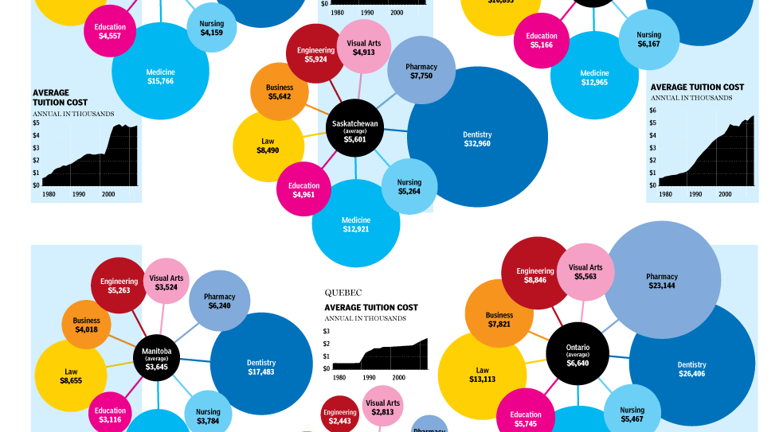

# Motivation

- Why are some plots easier to read than others?

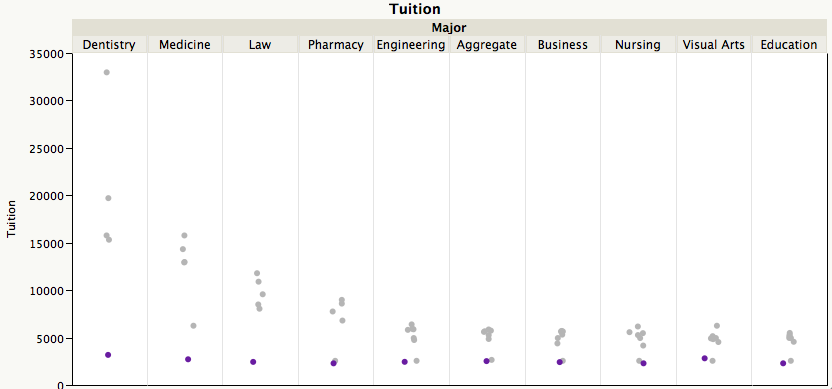

# Good Graphics

Graphics consist of:

- Structure (boxplot, scatterplot, etc.)
- Aesthetics: features such as color, shape, and size that map other characteristics to structural features

Both the structure and aesthetics should help viewers interpret the information.

# Pre-Attentive Features

- Things that “jump out” in less than 250 ms
- Color, form, movement, spatial localization

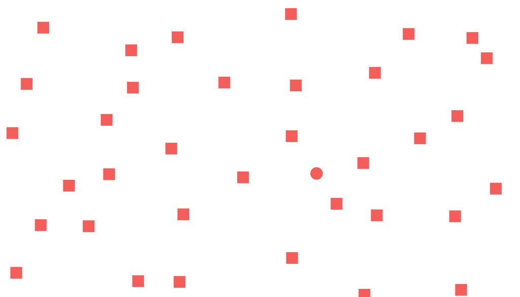

# Pre-attentive

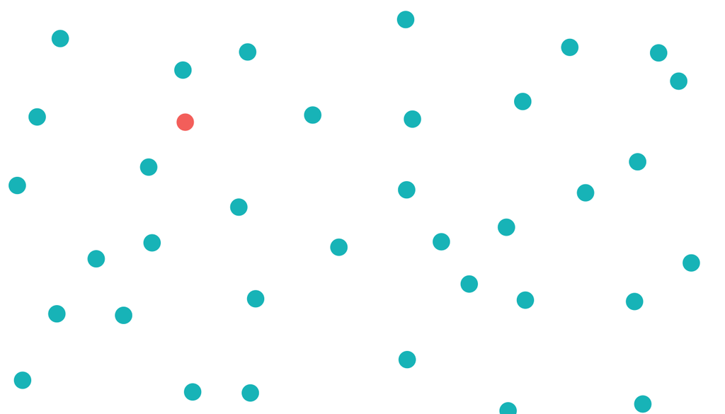

# Hierarchy of Features

- Color is stronger than shape
- Combinations of pre-attentive features are usually not pre-attentive due to **interference**

# Another One

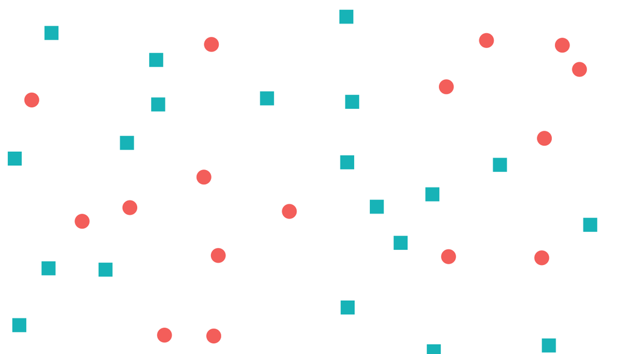

# One More

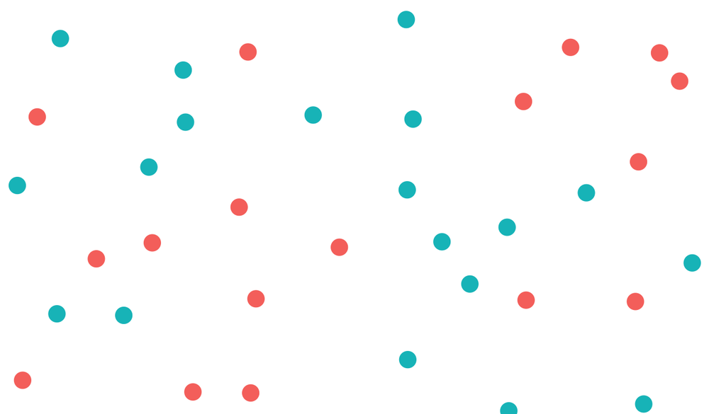

# Color

- Hue: shade of color (red, orange, yellow…)
- Intensity: amount of color
- Both color and hue are pre-attentive. Bigger contrast corresponds to faster detection.

# More Color

Color is context-sensitive: A and B are the same intensity and hue, but appear to be different.

[figure not shown]

# Aesthetics in `ggplot2`

Main parameters: alpha, shape, color, size

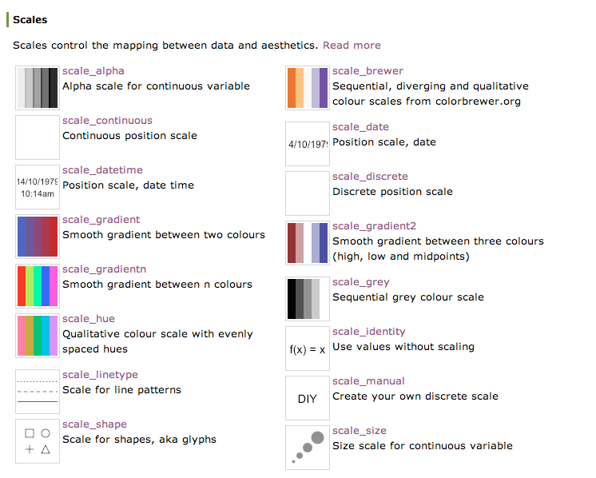

# Your Turn

Find ways to improve the following graphic:

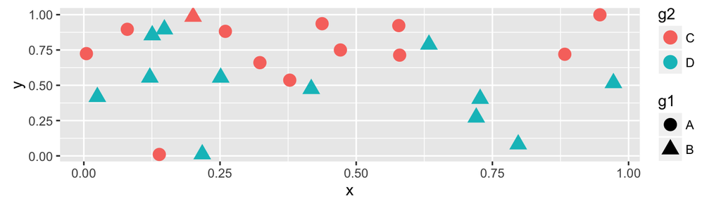

```r
frame <- read.csv("http://heike.github.io/rwrks/02-r-graphics/data/frame.csv")
qplot(x, y, data = frame, shape = g1, colour = g2, size = I(4))
```

- Make sure the “oddball” stands out while keeping the information on the groups
- Hint: `interaction` combines factor variables

# Ordering Variables

Which is bigger?

- Position: higher is bigger (y), items to the right are bigger (x)
- Size, Area
- Color: not always ordered. More contrast = bigger.
- Shape: Unordered.

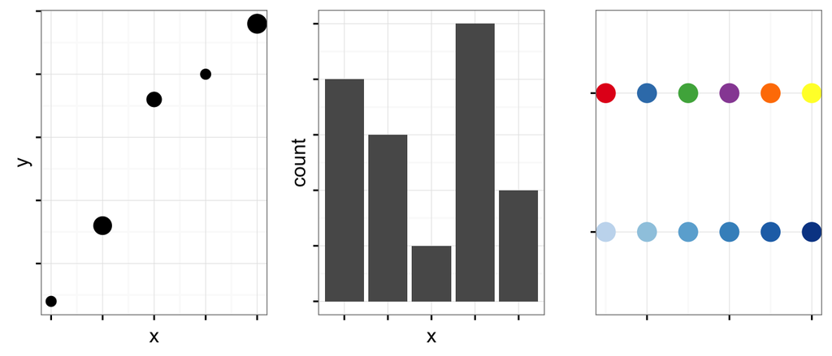

# Gradients

Qualitative schemes: no more than 7 colors

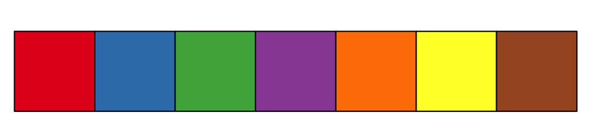

Quantitative schemes: use color gradient with only one hue for positive values

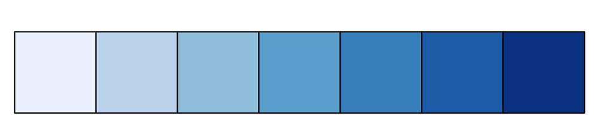

# More Gradients

Quantitative schemes: use color gradient with two hues for positive and negative values. Gradient should go through a light, neutral color (white)

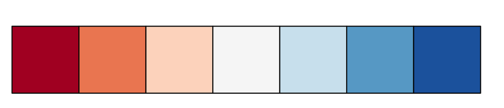

Small objects or thin lines need more contrast than larger areas

# RColorBrewer

R package based on Cynthia Brewer’s color schemes (http://www.colorbrewer2.org)

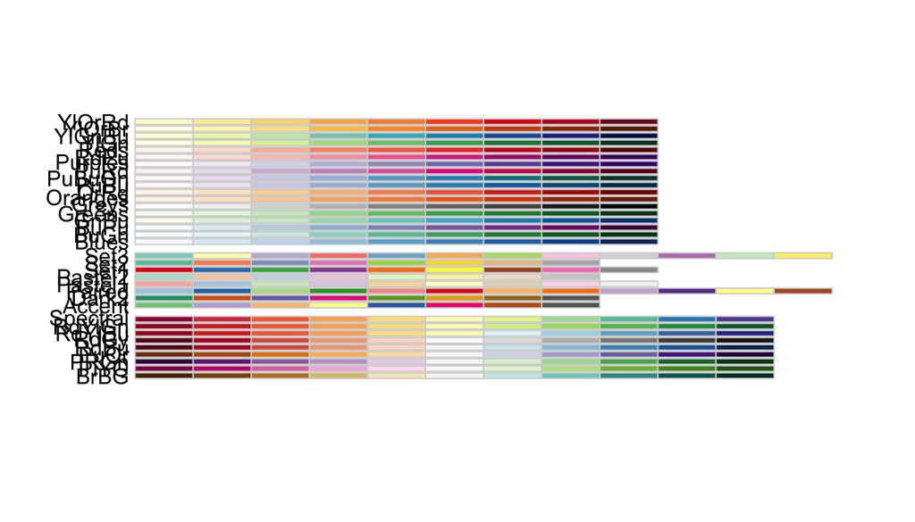

```r
display.brewer.all()
```

# Color in `ggplot2`

- Factor variable:
  - `scale_colour_discrete`
  - `scale_colour_brewer(palette = ...)`
- Continuous variable:
  - `scale_colour_gradient` (define low, high values)
  - `scale_colour_gradient2` (define low, mid, and high values)
  - Equivalents for fill: `scale_fill_...`

# Your Turn

- In the diamonds data, clarity and cut are ordinal, while price and carat are continuous
- Find a graphic that gives an overview of these four variables while respecting their types
- Hint: Start with the following code

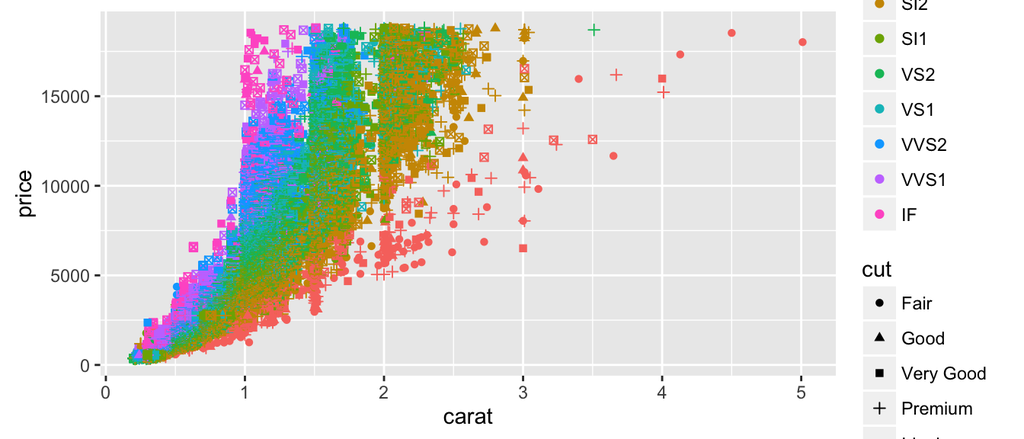

```r
qplot(carat, price, shape = cut, colour = clarity, data = diamonds)
```

# Facetting

- A way to extract subsets of data and place them side-by-side in graphics
- Syntax: `facets = row ~ col` Use `.` if there is no variable for either row or column (i.e. `facets = . ~ col`)

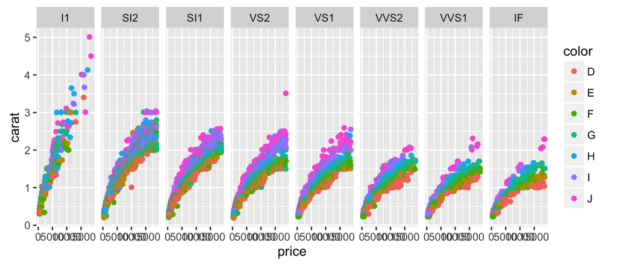

```r
qplot(price, carat, data = diamonds, color = color, facets = . ~ clarity)
```

# Your Turn

The `movies` dataset contains information from IMDB.com including ratings, genre, length in minutes, and year of release.

```r
movies <- read.csv("http://heike.github.io/rwrks/02-r-graphics/data/MovieSummary.csv")
```

- Explore the differences in length, rating, etc. in movie genres over time
- Hint: use facetting!